# This is an R Markdown document containing R analyses for the following paper:

Hogle SL, Dupont CL, Thrash JC, Barbeau KA. Trace metal acquisition by heterotrophic bacterioplankton with contrasting trophic strategies. mBio

## Ordination and multivariate statistics

Here we perform principle components analysis (PCA) and non-metric multidimmensional scaling (NMDS) in order to explore patterns of metal uptake genes in Roseobacter and SAR11. We also look at multivariate homogeneity of group dispersions for each taxonomic class in both NMDS and PCA ordinations in order to determine which group is more variable in terms of their transport capabilities.

### Load required libraries

```r
library("ggplot2")
library("vegan")
library("grid")
library("MASS")
```

### Import the dataset

```r
metalCountData <- read.table("sar11_roseo_metaluptake_counts.tsv", sep="\t", row.names=1, header=TRUE)
genomeFeat <- read.table("sar11_roseo_genome_feat.tsv", sep="\t", row.names=1, header=TRUE)
genomeCategories <- read.table("sar11_roseo_categories.tsv", row.names=1, header=TRUE)
```

### Create reduced dataframes

```r
# Dataframes without rows containing NA values in the Lifestyle category. Necessary for envfit analysis of factors
metalCountData.reduc <- metalCountData[!is.na(genomeCategories$Lifestyle), ]
genomeCategories.reduc <- genomeCategories[!is.na(genomeCategories$Lifestyle), ]
```

### Vegan implementation of PCA

```r
metal.rda <- rda(metalCountData)
# PCA on reduced dataset
metal.rda.reduc <- rda(metalCountData.reduc)
```

### Fit environmental factors onto the reduced ordination

```r
set.seed(753)
# Using Lifestyle factor for environmnetal fitting
ef.reduc <- envfit(metal.rda.reduc, genomeCategories.reduc, permu=999)
ef.reduc
```

```
##
## ***FACTORS:
##
## Centroids:
##                            PC1     PC2
## LifestyleFreeliving    -0.5893  0.1681
## LifestyleSurface_assoc  0.6161 -0.1757
## TaxaRoseobacter         0.6262 -0.1673
## TaxaSAR11              -0.6547  0.1749
##
## Goodness of fit:
##               r2 Pr(>r)
## Lifestyle 0.3284  0.001 ***
## Taxa      0.3674  0.001 ***
## ---
## Signif. codes:  0 '***' 0.001 '**' 0.01 '*' 0.05 '.' 0.1 ' ' 1
## Permutation: free
## Number of permutations: 999
```

Here we see that both the classifications of taxa (Roseobacter vs SAR11) and the classification of Lifestyle (surface associated/patch adapted vs freeliving) are significantly associated with the ordination. So the differences in metal transporter repretoir appear to be related to the differences between taxa and Lifestyle.

### Multivariate homogeneity of group dispersions

Here we calculate dispersion values for euclidean distance based on SAR11 vs Roseobacter groups in order to determine which group has a larger dsipersion or spread

```r
# Need to do dispersion calculation on a distance matrix. Use euclidean because PCA uses euclidean distances
metal_tran_dis <- vegdist(metalCountData, method = "euclidean")
disper <- betadisper(metal_tran_dis, genomeCategories$Taxa, bias.adjust=TRUE)
disper
```

```
##
##  Homogeneity of multivariate dispersions
##
## Call: betadisper(d = metal_tran_dis, group =
## genomeCategories$Taxa, bias.adjust = TRUE)
##
## No. of Positive Eigenvalues: 40
## No. of Negative Eigenvalues: 0
##
## Average distance to median:
## Roseobacter       SAR11
##       4.278       1.112
##
## Eigenvalues for PCoA axes:
##    PCoA1    PCoA2    PCoA3    PCoA4    PCoA5    PCoA6    PCoA7    PCoA8
## 737.4761 186.1731  91.6971  52.1355  35.0828  27.6643  24.7258  22.2809
```

```r
permutest(disper, pairwise = TRUE)
```

```
##
## Permutation test for homogeneity of multivariate dispersions
## Permutation: free
## Number of permutations: 999
##
## Response: Distances
##           Df Sum Sq Mean Sq      F N.Perm Pr(>F)
## Groups     1 144.69 144.694 60.194    999  0.001 ***
## Residuals 62 149.04   2.404
## ---
## Signif. codes:  0 '***' 0.001 '**' 0.01 '*' 0.05 '.' 0.1 ' ' 1
##
## Pairwise comparisons:
## (Observed p-value below diagonal, permuted p-value above diagonal)
##             Roseobacter SAR11
## Roseobacter             0.001
## SAR11        1.0391e-10
```

We can see here that Roseobacter has a greater average distance to median (4.278) compared to SAR11 (1.112) and that this difference is significant based on permuted model residuals generating a permutations distribution of F under the null hypothesis that there is no difference in dispersion between groups. This indicates that Roseobacter trace metal transporter inventory is more diverse and variable than in SAR11.

### Plotting the PCA analysis

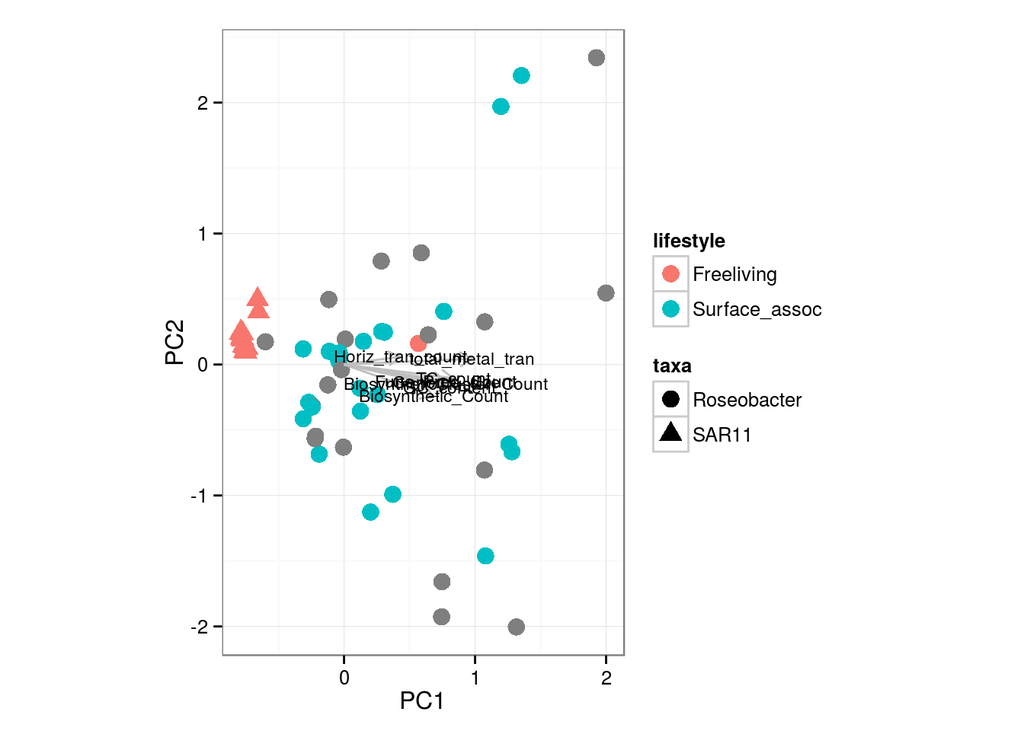

```r
### uses scores function to put site PC values into scrcs. Then associate a variable with them -
### in this case using the Lifestyle category. The result is a dataframe
scrs <- as.data.frame(scores(metal.rda, display = "sites"))
scrs <- cbind(scrs, lifestyle = genomeCategories$Lifestyle, taxa = genomeCategories$Taxa)

set.seed(152)
ef <- envfit(metal.rda, genomeFeat, permu = 999)


### use the score function again to load direction of vectors. Vectors here are weighted by r2 value
spp.scrs <- as.data.frame(scores(ef, display = "vectors"))
spp.scrs <- cbind(spp.scrs, Species = rownames(spp.scrs))

### make the ggplot object
ggplot(scrs) +
  geom_point(mapping = aes(x = PC1, y = PC2, shape = taxa, color = lifestyle), size = 4) +
  theme_bw() +
  coord_fixed() + ## need aspect ratio of 1!
  geom_segment(data = spp.scrs, aes(x = 0, xend = PC1, y = 0, yend = PC2), arrow = arrow(length = unit(0.25, "cm")), colour = "grey") +
  geom_text(data = spp.scrs, aes(x = PC1, y = PC2, label = Species), size = 3)
```

### Vegan implementation of NMDS

We’ll now perform the same analysis as above using NMDS. NMDS is a popular and very robust ordination method, and it is frequently used in microbial ecology studies. We want to make sure that NMDS and PCA (both based on differing assumptions) don’t provide wildly different results.

```r
set.seed(471)
metal.mds <- metaMDS(metalCountData, trace = TRUE, plot = F, autotransform = FALSE, noshare = FALSE, wascores = FALSE, trymax = 1000)
```

```
## ... procrustes: rmse 0.008973122  max resid 0.04651044
## ... procrustes: rmse 0.06409011  max resid 0.3321104
## ... procrustes: rmse 0.05271375  max resid 0.1365035
## ... procrustes: rmse 0.006515735  max resid 0.03648933
## ... procrustes: rmse 0.001932787  max resid 0.006878349
## *** Solution reached
```

### Multivariate homogeneity of group dispersions for NMDS

The same analysis as above but using Bray-Curtis distance. This is the default dissimilarity matrix used in the metaMDS function.

```r
# Need to do dispersion calculation on a distance matrix. Use bray distance
metal_tran_dis <- vegdist(metalCountData, method = "bray")
disper <- betadisper(metal_tran_dis, genomeCategories$Taxa, bias.adjust=TRUE)
disper
```

```
##
##  Homogeneity of multivariate dispersions
##
## Call: betadisper(d = metal_tran_dis, group =
## genomeCategories$Taxa, bias.adjust = TRUE)
##
## No. of Positive Eigenvalues: 26
## No. of Negative Eigenvalues: 30
##
## Average distance to median:
## Roseobacter       SAR11
##      0.3628      0.3426
##
## Eigenvalues for PCoA axes:
##  PCoA1  PCoA2  PCoA3  PCoA4  PCoA5  PCoA6  PCoA7  PCoA8
## 7.4161 2.0080 1.4299 0.9981 0.8239 0.7594 0.6977 0.6206
```

```r
permutest(disper, pairwise = TRUE)
```

```
##
## Permutation test for homogeneity of multivariate dispersions
## Permutation: free
## Number of permutations: 999
##
## Response: Distances
##           Df Sum Sq   Mean Sq      F N.Perm Pr(>F)
## Groups     1 0.0059 0.0058997 0.2734    999  0.611
## Residuals 62 1.3378 0.0215781
##
## Pairwise comparisons:
## (Observed p-value below diagonal, permuted p-value above diagonal)
##             Roseobacter SAR11
## Roseobacter             0.602
## SAR11           0.60292
```

So it looks like there is no significant difference in group dispersion between Roseobacter or SAR11 in the NMDS/Bray-Curtis case. Why is this result different than that for PCA which relies on a Euclidean dissimilarity structure? Let’s plot the NMDS plot to look closer…

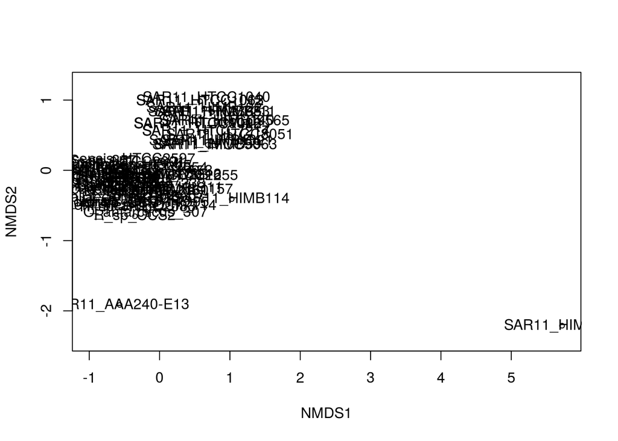

```r
plot(metal.mds, type = "p")
text(metal.mds, display = "sites")
```

In the NMDS ordination it looks like both AAA240-E13 and HIMB058 are big outliers. These genomes are not complete and/or amplified by MDA so they might not be refelecting a real trend here (potentially missing genes related to metal transport). Since NMDS is based on rank rather than absolute distances you lose information regarding the large differences in magnitude that you would expect with an analysis like PCA between SAR11 and Roseobacter. For example, instead of HTCC1002 being X arbitrary units away from Ruegeria TrichCH4B, HTCC1002 would be the “first, second, or third and so on” most distant object from CH4B. In that respect, in NMDS a lot of the biggest differences in magnitude between positioning in the ordination get compressed while smaller changes tend to be amplified.

```r
set.seed(471)
metalCountData.NOSAG <- metalCountData[-c(42,43), ]     #remove AAA240-E13 and HIMB058
genomeCategories.NOSAG <- genomeCategories[-c(42,43), ] #remove AAA240-E13 and HIMB058
genomeFeat.NOSAG <- genomeFeat[-c(42,43), ]             #remove AAA240-E13 and HIMB058

metal.mds.NOSAG <- metaMDS(metalCountData.NOSAG, trace = TRUE, plot = F, autotransform = FALSE, noshare = FALSE, wascores = FALSE, trymax = 1000)
```

```
## ... procrustes: rmse 0.003718555  max resid 0.01963279
## ... procrustes: rmse 0.003292331  max resid 0.01538293
## ... procrustes: rmse 0.003516377  max resid 0.02218278
## ... procrustes: rmse 0.005829302  max resid 0.03454454
## ... procrustes: rmse 0.00501204  max resid 0.03359612
## ... procrustes: rmse 7.917323e-05  max resid 0.0003379384
## *** Solution reached
```

Now we’ll look again at the group dispersions

```r
# Need to do dispersion calculation on a distance matrix. Use bray distance
metal_tran_dis.NOSAG <- vegdist(metalCountData.NOSAG, method = "bray")
disper.NOSAG <- betadisper(metal_tran_dis.NOSAG, genomeCategories.NOSAG$Taxa, bias.adjust=TRUE)
disper.NOSAG
```

```
##
##  Homogeneity of multivariate dispersions
##
## Call: betadisper(d = metal_tran_dis.NOSAG, group =
## genomeCategories.NOSAG$Taxa, bias.adjust = TRUE)
##
## No. of Positive Eigenvalues: 25
## No. of Negative Eigenvalues: 29
##
## Average distance to median:
## Roseobacter       SAR11
##      0.3628      0.2856
##
## Eigenvalues for PCoA axes:
##  PCoA1  PCoA2  PCoA3  PCoA4  PCoA5  PCoA6  PCoA7  PCoA8
## 7.4055 1.9920 1.1716 0.9338 0.7788 0.7025 0.6375 0.5098
```

```r
permutest(disper.NOSAG, pairwise = TRUE)
```

```
##
## Permutation test for homogeneity of multivariate dispersions
## Permutation: free
## Number of permutations: 999
##
## Response: Distances
##           Df  Sum Sq  Mean Sq      F N.Perm Pr(>F)
## Groups     1 0.08071 0.080712 9.5915    999  0.005 **
## Residuals 60 0.50490 0.008415
## ---
## Signif. codes:  0 '***' 0.001 '**' 0.01 '*' 0.05 '.' 0.1 ' ' 1
##
## Pairwise comparisons:
## (Observed p-value below diagonal, permuted p-value above diagonal)
##             Roseobacter SAR11
## Roseobacter             0.002
## SAR11         0.0029714
```

Now these dispersion differences appear to be significant - albeit they are smaller in magnitude than what we saw for the euclidean distance in the PCA analysis. Still it is good to see the two methods generally agreeing, even though their underlying assumptions are quite different. Let’s now plot up the NMDS ordination missing the potentially incomplete genomes

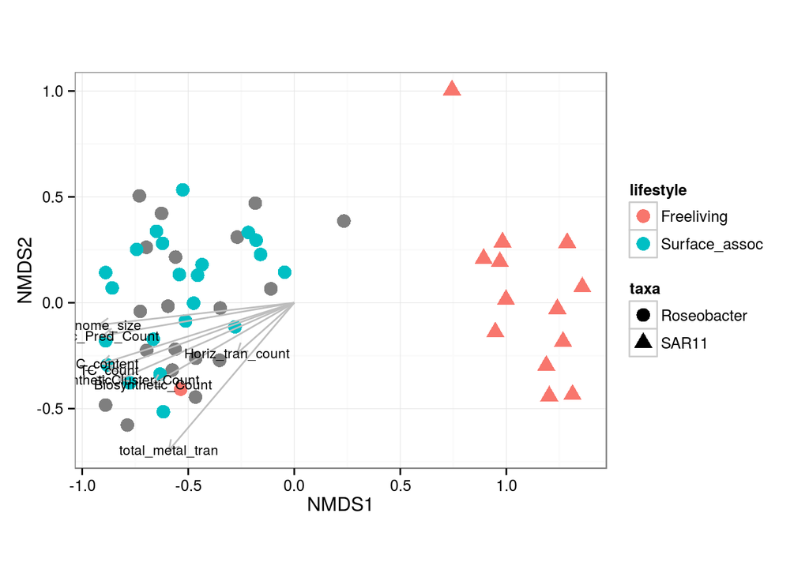

```r
### uses scores function to put site PC values into scrcs. Then associate a variable with them -
### in this case using the Lifestyle category. The result is a dataframe
scrs.mds <- as.data.frame(scores(metal.mds.NOSAG, display = "sites"))
scrs.mds <- cbind(scrs.mds, lifestyle = genomeCategories.NOSAG$Lifestyle, taxa = genomeCategories.NOSAG$Taxa)

set.seed(152)
ef.mds <- envfit(metal.mds.NOSAG, genomeFeat.NOSAG, permu = 999)

### use the score function again to load direction of vectors. Vectors here are weighted by r2 value
spp.scrs.mds <- as.data.frame(scores(ef.mds, display = "vectors"))
spp.scrs.mds <- cbind(spp.scrs.mds, Species = rownames(spp.scrs.mds))

### make the ggplot object
ggplot(scrs.mds) +
  geom_point(mapping = aes(x = NMDS1, y = NMDS2, shape = taxa, color = lifestyle), size = 4) +
  theme_bw() +
  coord_fixed() + ## need aspect ratio of 1!
  geom_segment(data = spp.scrs.mds, aes(x = 0, xend = NMDS1, y = 0, yend = NMDS2), arrow = arrow(length = unit(0.25, "cm")), colour = "grey") +
  geom_text(data = spp.scrs.mds, aes(x = NMDS1, y = NMDS2, label = Species), size = 3)
```

## Conclusion

It appears that PCA seems to be more sensitive to the “double zero problem” which is that ecological sites will tend to cluster based on species with many shared absences as opposed to those species with shared presences (paraphrased from Numerical Ecology by Legendre and Legendre). This is cited as a problem by Legendre and Legendre because traditional ecological studies treat double zeros aka shared absences of species as uninformative presumably due to the risk of false negatives. However, in our case zero values are true values. The absence of a gene in a set of genomes **is** actually informative in our case given that our risk for false negatives is effectively zero (albeit except for cases of the SAG and mda genomes). Therefore, we think that euclidean distance PCA best represents our data here. We do need to be careful about genome completeness, but at this stage in our exploratory analysis we think that it is unnecessary to omit AAA240-E13 and HIMB058 as they represent valuable phylogenetic diversity not encompassed by the other strains.